# Udemy Finance and Accounting Courses Analysis

Anirudh Dhagate

2024-08-31

# Udemy Finance and Accounting Courses Analysis

This document contains the analysis of development-related courses available on Udemy under the Finance and Accounting categories. The dataset includes 13,111 courses and contains various columns such as course ID, title, URL, subscriber count, ratings, review count, number of lectures, number of practice tests, pricing information, and more.

## 1. Data Loading and Initial Inspection

We start by loading the necessary libraries and the dataset, followed by an initial inspection of the data.

```r
setwd("D:/Projects/R Projects/Finance and Accounting courses Analysis")

library(tidyverse)
```

```r
library(ggplot2)
library(dplyr)
library(readr)

data <- read_csv("D:/Projects/R Projects/Finance and Accounting courses Analysis/data/udemy_finance_accounting.csv")
head(data)
```

```
## # A tibble: 6 × 20
##       id title url   is_paid num_subscribers avg_rating avg_rating_recent rating
##    <dbl> <chr> <chr> <lgl>             <dbl>      <dbl>             <dbl>  <dbl>
## 1 7.63e5 The … /cou… TRUE             295509       4.66              4.68   4.68
## 2 9.38e5 Tabl… /cou… TRUE             209070       4.59              4.60   4.60
## 3 1.36e6 PMP … /cou… TRUE             155282       4.59              4.59   4.59
## 4 6.49e5 The … /cou… TRUE             245860       4.54              4.54   4.54
## 5 6.38e5 An E… /cou… TRUE             374836       4.47              4.47   4.47
## 6 1.21e6 Micr… /cou… TRUE             124180       4.56              4.58   4.58
## # ℹ 12 more variables: num_reviews <dbl>, is_wishlisted <lgl>,
## #   num_published_lectures <dbl>, num_published_practice_tests <dbl>,
## #   created <dttm>, published_time <dttm>, discount_price__amount <dbl>,
## #   discount_price__currency <chr>, discount_price__price_string <chr>,
## #   price_detail__amount <dbl>, price_detail__currency <chr>,
## #   price_detail__price_string <chr>
```

```r
View(data)
colnames(data)
```

```
##  [1] "id"                           "title"
##  [3] "url"                          "is_paid"
##  [5] "num_subscribers"              "avg_rating"
##  [7] "avg_rating_recent"            "rating"
##  [9] "num_reviews"                  "is_wishlisted"
## [11] "num_published_lectures"       "num_published_practice_tests"
## [13] "created"                      "published_time"
## [15] "discount_price__amount"       "discount_price__currency"
## [17] "discount_price__price_string" "price_detail__amount"
## [19] "price_detail__currency"       "price_detail__price_string"
```

## 2. Data Cleaning and Preprocessing

### Dropping Irrelevant Columns

Some columns are not necessary for the analysis (e.g., currency columns), so we remove them.

```r
data <- subset(data, select = -c(discount_price__currency, discount_price__price_string, price_detail__currency, price_detail__price_string))
```

### Renaming Columns

We rename the columns to make them more descriptive and easier to use in analysis.

```r
replace_names = c(course_id = "id", course_title = "title", course_url = "url", subscriber_count = "num_subscribers", review_count = "num_reviews", discounted_price = "discount_price__amount", actual_price = "price_detail__amount")
data <- data %>%
  rename(replace_names)
```

### Handling Missing Data

We identify and handle missing data, dropping rows where `actual_price` is missing and setting `discounted_price` to 0 where it is missing.

```r
data <- data %>%
  filter(!is.na(actual_price)) %>%
  mutate(discounted_price = replace_na(discounted_price, 0))

colSums(is.na(data))
```

```
##                    course_id                 course_title
##                            0                            0
##                   course_url                      is_paid
##                            0                            0
##             subscriber_count                   avg_rating
##                            0                            0
##            avg_rating_recent                       rating
##                            0                            0
##                 review_count                is_wishlisted
##                            0                            0
##       num_published_lectures num_published_practice_tests
##                            0                            0
##                      created               published_time
##                            0                            0
##             discounted_price                 actual_price
##                            0                            0
```

### Rounding Numerical Columns

To make the data easier to work with, we round numerical columns to two decimal places.

```r
round_to_decimal <- function(x, digits = 2) {
  if (is.numeric(x)) {
    return(round(x, digits))
  } else {
    return(x)
  }
}

data <- data %>%
  mutate_all(round_to_decimal)
```

## 3. Descriptive Analysis

### Price Distribution

We explore the price distribution of the courses using a histogram.

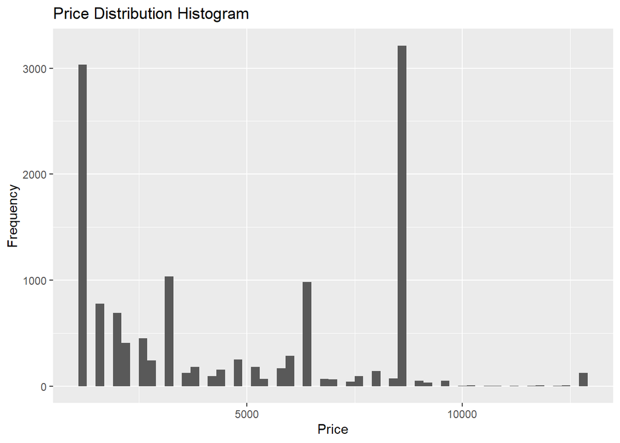

```r
ggplot(data, aes(x = actual_price)) +
  geom_histogram(binwidth = 200) +
  labs(title = "Price Distribution Histogram", x = "Price", y = "Frequency")
```

### Discount Analysis

We calculate the average discount percentage and visualize the distribution of discount percentages across courses.

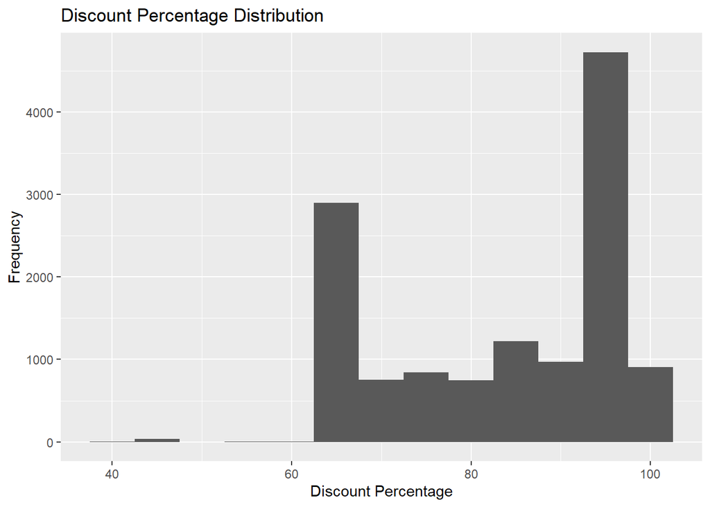

```r
data <- data %>%
  mutate(discount_percentage = ((actual_price - discounted_price) / actual_price) * 100)

ggplot(data, aes(x = discount_percentage)) +
  geom_histogram(binwidth = 5) +
  labs(title = "Discount Percentage Distribution", x = "Discount Percentage", y = "Frequency")
```

### Subscriber Analysis

We compare the subscriber count for discounted versus non-discounted courses.

```r
discounted_courses <- data %>%
  filter(discounted_price > 0) %>%
  arrange(desc(subscriber_count))
top_discounted_courses <- head(discounted_courses, 20)
non_discounted_courses <- data[data$discounted_price == 0, ] %>%
  arrange(desc(subscriber_count)) %>%
  head(, 20)



# difference in subscriber count (discounted vs non-discounted courses)
discounted_course_subscriber_count <- sum(top_discounted_courses$subscriber_count)
non_discounted_course_subscriber_count <- sum(non_discounted_courses$subscriber_count)
discounted_course_subscriber_count - non_discounted_course_subscriber_count
```

```
## [1] 3005464
```

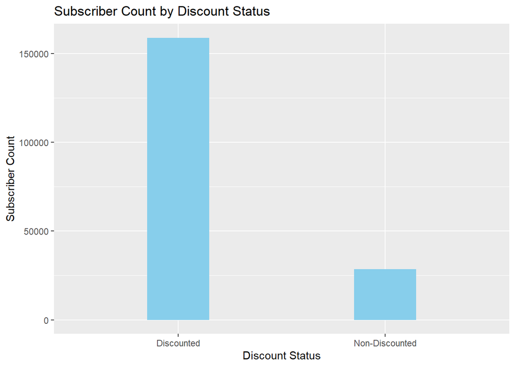

```r
mean_discounted_subscribers <- mean(top_discounted_courses$subscriber_count)
mean_non_discounted_subscribers <- mean(non_discounted_courses$subscriber_count)

plot_data <- data.frame(
  category = c("Discounted", "Non-Discounted"),
  subscriber_count = c(mean_discounted_subscribers, mean_non_discounted_subscribers)
)

ggplot(plot_data, aes(x = category, y = subscriber_count)) +
  geom_bar(stat = "identity", fill = "skyblue", width = 0.3) +
  labs(title = "Subscriber Count by Discount Status",
       x = "Discount Status",
       y = "Subscriber Count")
```

## 4. Subscriber Growth Over Time

### Aggregating Subscriber Count by Year-Month

We create a `year_month` column to aggregate subscriber counts and visualize the growth over time.

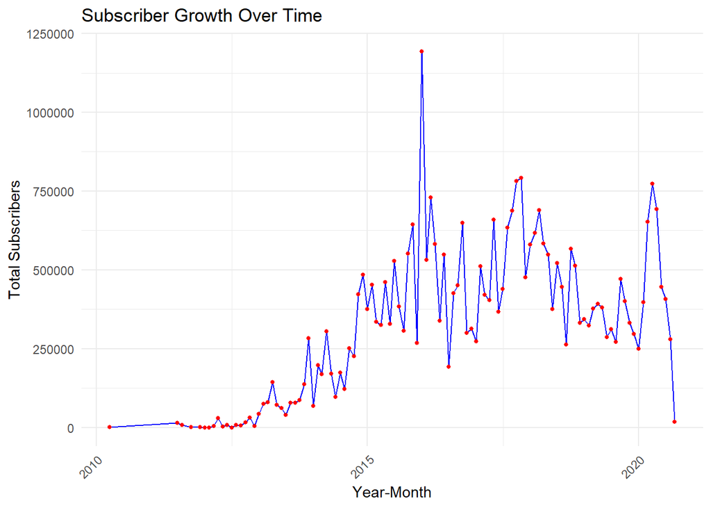

```r
data <- data %>%
  mutate(year_month = format(as.Date(published_time), "%Y-%m"))

subscriber_trend <- data %>%
  group_by(year_month) %>%
  summarize(total_subscribers = sum(subscriber_count))

subscriber_trend <- subscriber_trend %>%
  mutate(year_month = as.Date(paste0(year_month, "-01")))

ggplot(subscriber_trend, aes(x = year_month, y = total_subscribers)) +
  geom_line(color = "blue") +
  geom_point(color = "red", size = 1) +
  labs(title = "Subscriber Growth Over Time",
       x = "Year-Month",
       y = "Total Subscribers") +
  theme_minimal() +
  theme(axis.text.x = element_text(angle = 45, hjust = 1))
```

## 5. Lecture and Test Analysis

### Number of Lectures vs. Subscriber Count

We visualize the relationship between the number of lectures and the subscriber count.

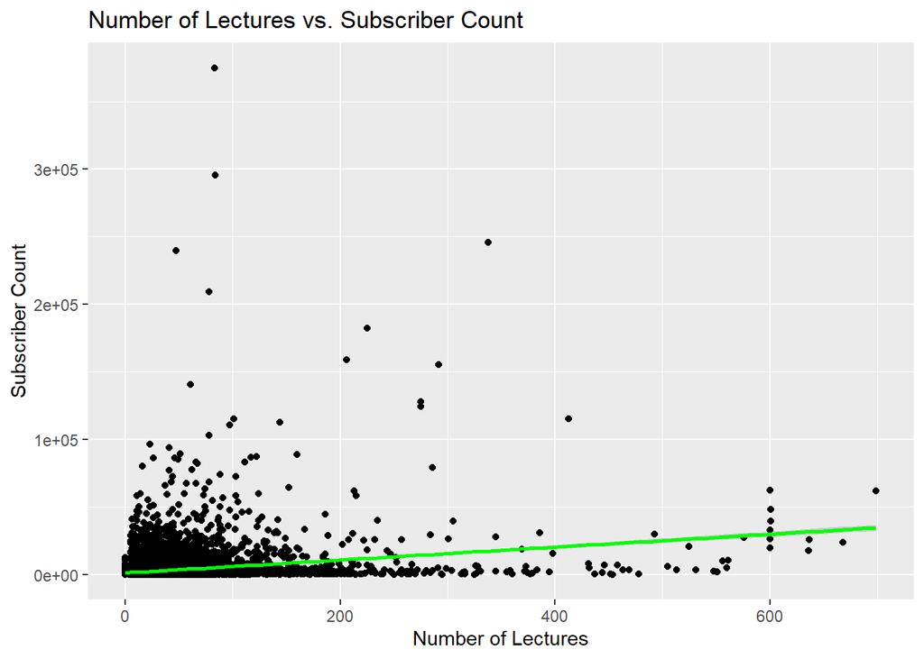

```r
ggplot(data, aes(x = num_published_lectures, y = subscriber_count)) +
  geom_point() +
  geom_smooth(method = "lm", color = "green") +
  labs(title = "Number of Lectures vs. Subscriber Count", x = "Number of Lectures", y = "Subscriber Count")
```

### Number of Practice Tests vs. Ratings

We explore the relationship between the number of practice tests and the course ratings.

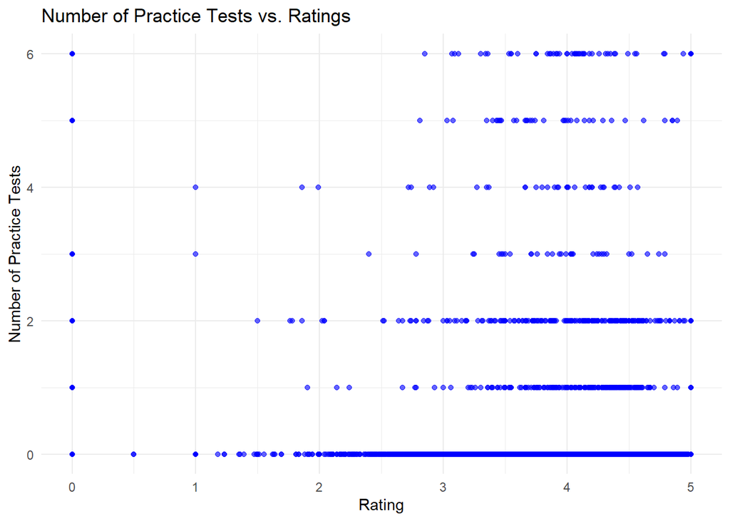

```r
ggplot(data, aes(x = rating, y = num_published_practice_tests)) +
  geom_point(color = "blue", alpha = 0.6) +
  labs(title = "Number of Practice Tests vs. Ratings",
       x = "Rating",
       y = "Number of Practice Tests") +
  theme_minimal()
```

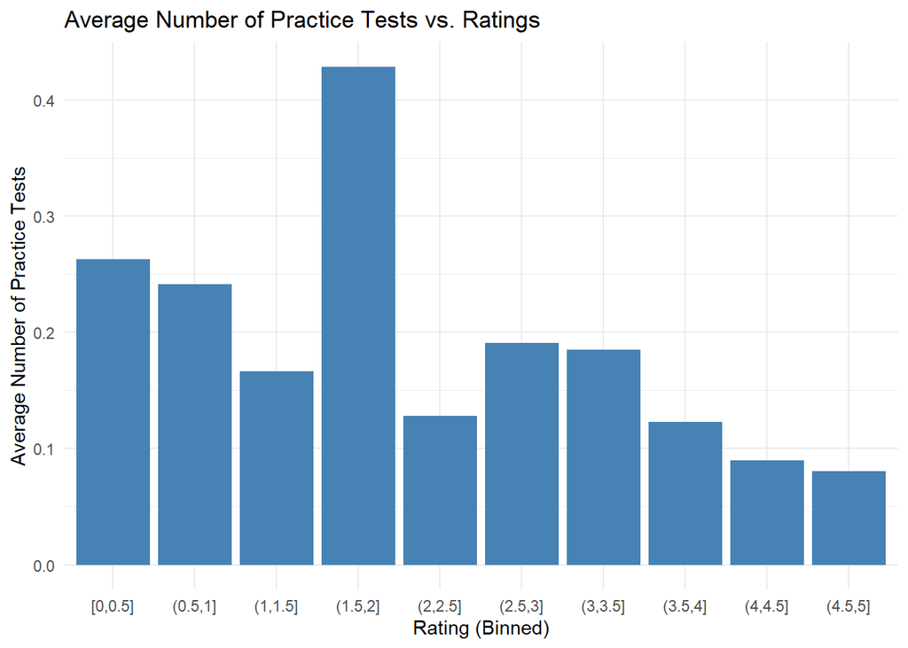

```r
# Binned Ratings vs. Average Number of Practice Tests
data <- data %>%
  mutate(rating_bin = cut(rating, breaks = seq(0, 5, by = 0.5), include.lowest = TRUE))

average_practice_tests <- data %>%
  group_by(rating_bin) %>%
  summarize(avg_practice_tests = mean(num_published_practice_tests, na.rm = TRUE))

ggplot(average_practice_tests, aes(x = rating_bin, y = avg_practice_tests)) +
  geom_bar(stat = "identity", fill = "steelblue") +
  labs(title = "Average Number of Practice Tests vs. Ratings",
       x = "Rating (Binned)",
       y = "Average Number of Practice Tests") +
  theme_minimal()
```